# Forecasting Average Weekly Traffic Volume

CSCI E-116 Final Project Report

Rebeca Ansar

2022-12-10

# Purpose

Effectively forecasting traffic volume across time can assist a variety of interested parties, including government officials who may need to find the least disruptive yearly timeframes for highway upkeep and traffic engineers who monitor the efficiency of the traffic flow.

The goal of this analytics project is to forecast the average weekly traffic volume for I-94 westbound traffic between Minneapolis and St Paul, MN crossing MN D0T ATR station 301, which is roughly midway between the two locations. To that end, several time series modeling methods were implemented and compared against each other in order to select the optimal forecasting model with minimal error.

# Methodology

## Data Exploration and Processing

| variable | data_type | description |
| --- | --- | --- |
| holiday | categorical | US national holidays and the MN State Fair regional holiday |
| temp | numeric | average temp in kelvin |
| rain_1h | numeric | amount of rain in the hour (mm) |
| snow_1h | numeric | amount of snow in the hour (mm) |
| clouds_all | numeric | percentage of cloud cover |
| weather_main | categorical | short text description of the current weather |
| weather_description | categorical | longer text description of the current weather |
| date_time | date_time | date and hour of the data collected in CST |
| traffic_volume | numeric | hourly I-94 ATR 301-reported westbound traffic volume |

I evaluated the various levels of each categorical variable. Because of the amount of detail in the levels and the requirements of the models I planned to build, I removed all categorical variables from consideration as predictors in the various models. I also converted all numerical features to average weekly values with the hope that a higher level of abstraction would allow models to identify patterns in the data. The date feature now contained weeks of the year. The list below contains the subset of transformed features from the data dictionary above that were utilized during model-building.

- avg_weekly_temp
- avg_weekly_rain_1h
- avg_weekly_snow_1h
- avg_weekly_clouds_all
- avg_weekly_traffic_volume

### Separating training and test data

After hourly data was converted into average weekly values, there were 269 total rows of data. Once the 80/20 train/test split was applied, 215 of those rows went into the training data and 54 rows were set aside as test data. All models were built using the training data and compared using the root mean squared error (RMSE) on the test data.

## Building models

### The benchmark model

As the first step of the model-building process, a benchmark model was constructed in order to obtain a measure of accuracy that would serve as a baseline for subsequent models. This benchmark is a naive linear model that predicts the current week’s average weekly traffic volume using the previous week’s value. The root mean squared error value was calculated on the test data (test RMSE) to obtain the necessary baseline.

### Using variable selection to build linear models

In the next step, other weekly features in addition to 4 lags of the outcome variable were considered as potential predictors that may improve model performance. Up to four lags were chosen because there are roughly four weeks in a month, and perhaps the behavior of average weekly traffic volume shows a monthly pattern. Variable selection was conducted using the various methods offered by the regsubsets() function. Two separate evaluation metrics were considered in order to build 2 linear models. When adjusted R-squared was chosen as the variable selection’s evaluation metric, 5 features were surfaced as the optimal count. These included the avg_weekly_temp, avg_weekly_snow_1h, and lags 1, 2 and 3 of avg_weekly_traffic_volume. When BIC was selected as the evaluation metric, 3 features were surfaced as the optimal count. These included avg_weekly_temp, avg_weekly_snow_1h, and lags 3 of avg_weekly_traffic_volume.

### ARIMA model

The ARIMA model was built using only the historical values of avg_weekly_traffic_volume in the training data. This model was then utilized to forecast test predictions, which were compared to the test data to obtain a test RMSE.

### Vector autoregressive model (VAR)

The VAR model was built with all 5 numerical variables, since the unit root test indicated that all of these features were stationary. To find the optimal value for the lag hyperparameter, a function named var_adj_r_squared_finder was created. This function iterated through 10 VAR models using a lag of 1 through 10 and outputted the lag that resulted in the highest model adjusted R-squared value.

A lag of 8 was optimal, which was used to construct the final VAR model. From there the model was utilized to predict values for the 54 weeks in the test data. And these forecasted values were compared to test data to obtain a test RMSE.

### Dynamic factor model (DFM)

A dynamic factor model was built with 4 principal components (PC’s) as the final model. First, a linear model was built to predict the avg_weekly_traffic_volume from all 4 principal components. The model summary showed that only PC1 and PC4 were statistically significant, so a second model was built with only those 2 principal components as predictors. However, the second model’s adjusted R-squared value was slightly lower than that of the first. The first model was retained as the final dynamic factor model.

Next, 3 VAR models were built with all 4 principal components using lags 1, 2, and 3. Since the different lags did not produce significantly different results, lag 1 was used as the hyperparameter value in the VAR model. This VAR model was utilized to forecast the values of the 4 principal components for the 54 weeks in the test set, and then those forecasted predictor values were then used to predict the outcome value for average weekly traffic volume using the very first linear model constructed in this section. The forecasted values were compared to the test data to obtain a test RMSE for this model.

# Results

The table below shows the test RMSE of each model, the model name, and the regressors used to build the model. The table is ordered by lowest test RMSE, so it lists models by best performing to worst performing.

|  | test_rmse | models | regressors |
| --- | --- | --- | --- |
| 3 | 223.85 | best_bic_3var_model | avg_weekly_snow_1h + avg_weekly_temp + lag(avg_weekly_traffic_volume, 3) |
| 2 | 225.19 | best_adjr2_5var_model | avg_weekly_snow_1h + avg_weekly_temp + + lag(avg_weekly_traffic_volume, 1)+ lag(avg_weekly_traffic_volume, 2) + lag(avg_weekly_traffic_volume, 3) |
| 4 | 228.30 | arima_model | auto-ARIMA with avg_weekly_traffic_volume |
| 1 | 229.11 | naive_lag_1_linear_model | lag(avg_weekly_traffic_volume, 1) |
| 5 | 233.96 | var_level_model | VAR with avg_weekly_traffic_volume, avg_weekly_temp, avg_weekly_rain_1h, avg_weekly_snow_1h, avg_weekly_clouds_all |
| 6 | 235.67 | dfm_lm1 | DFM with 4 principle components |

The model built by variable selection using the BIC evaluation metric and 3 predictors has the lowest test RMSE of 223.85. Thus, it is the optimal model for predicting average weekly traffic volume. However, the range of test RMSE values is quite narrow, and no model outperforms the others by a large margin. The dynamic factor model, which is arguably the most complex model, performs the worst, with the highest test RMSE of 235.67.

Next steps may include evaluating traffic data at a different frequency, such as daily or monthly with the goal of building less error-prone forecasting models. Additionally, more in-depth exploratory data analysis may surface necessary modifications to the model-building approach.

# Related Findings & Discussion

## Plots of the 5 time series variables

Below are the plots of the 5 numeric variables over time from the training data. Note that the 3 plots Average Weekly Traffic Volume, Average Weekly Temperature, and Average Weekly Percentage Cloud Cover show at least rough patterns whereas the plots Average Weekly Amount of Rain and Average Weekly Amount of Snow do not. The patterns for the latter two plots may be hidden due to the apparent outlier values occurring in Summer 2016 for rainfall and in Winter 2016 for snowfall. A next step could be to check the veracity of the data for these timeframes and perhaps remove it from consideration if these values prove to be unhelpful in producing reliable forecasts.

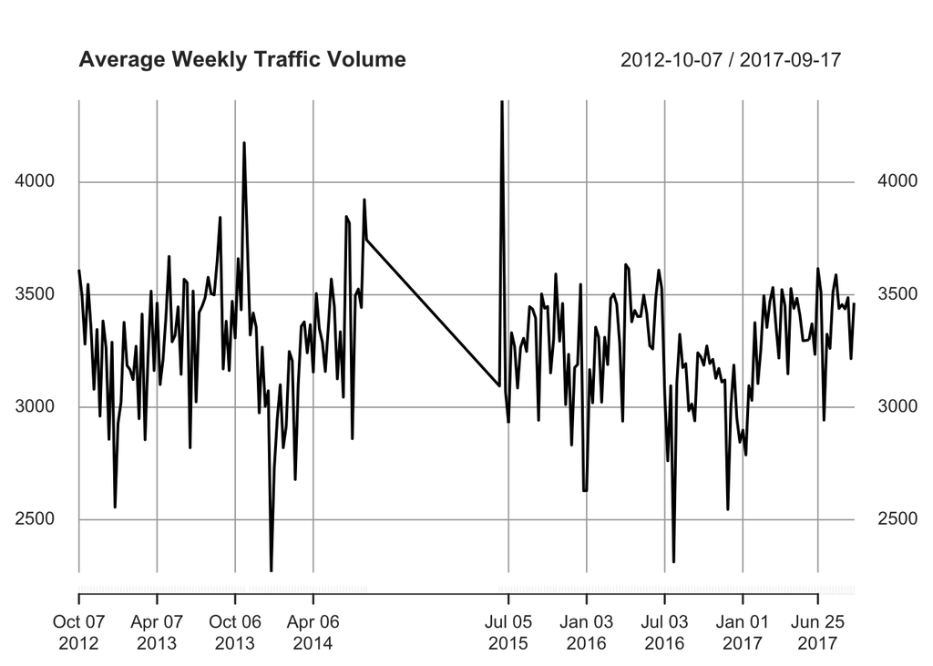

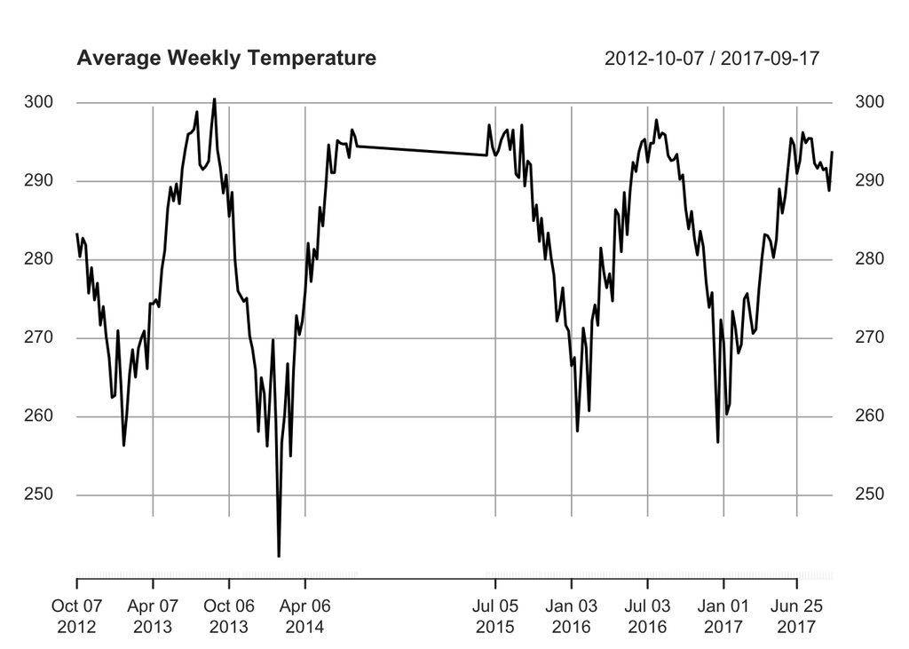

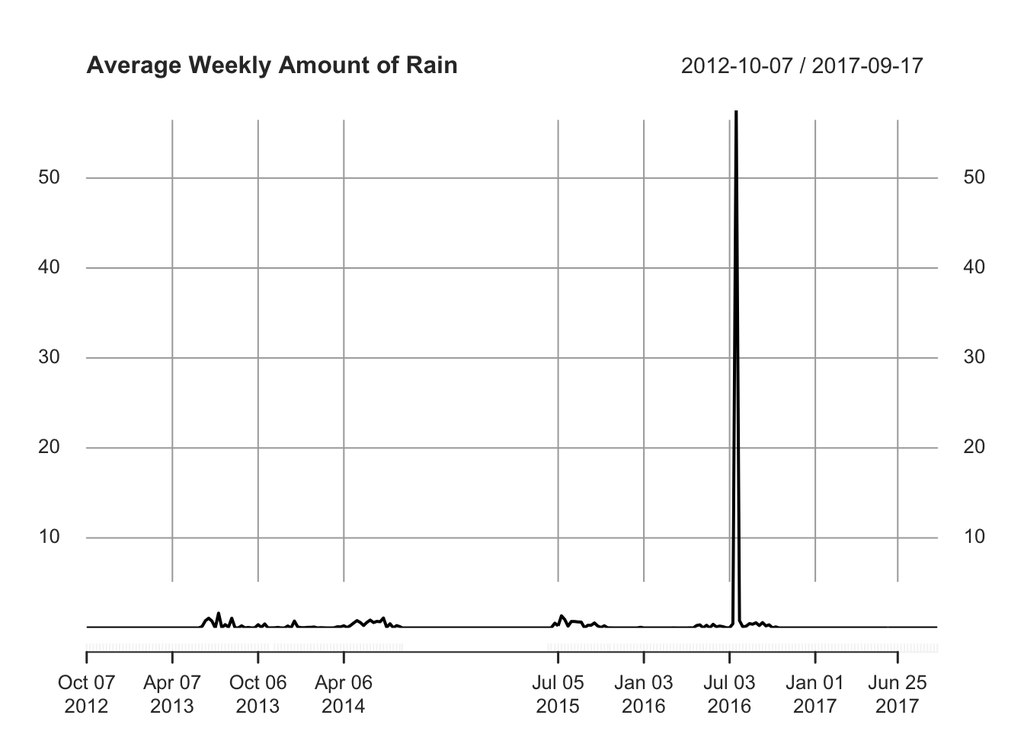

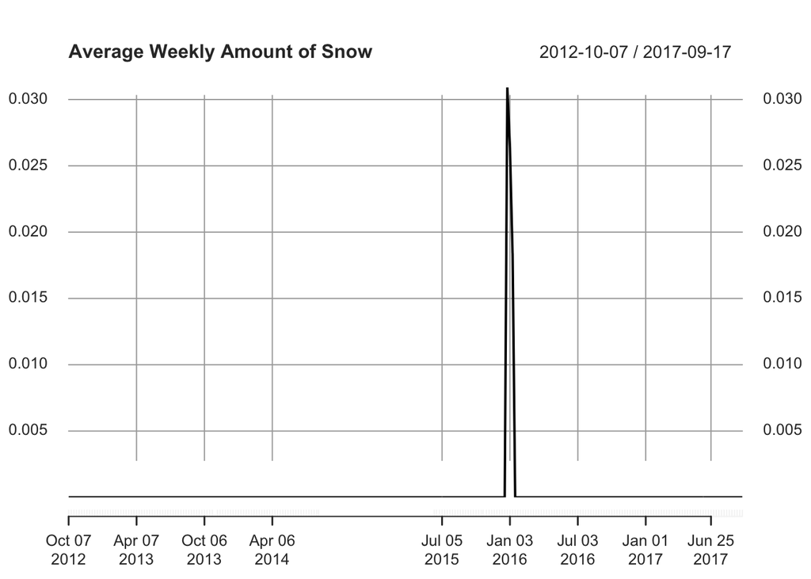

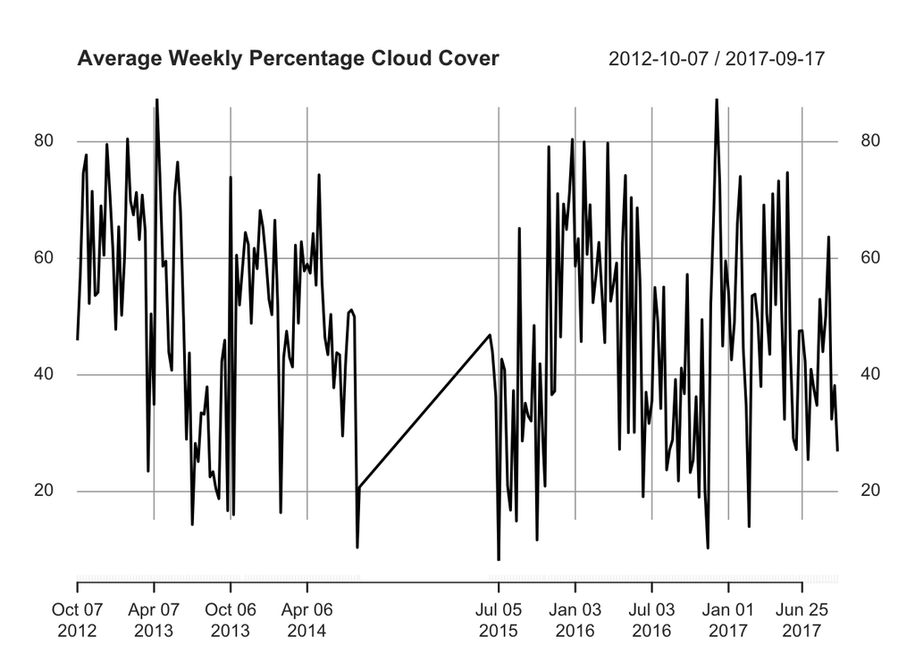

## Forecast from the ARIMA model

Below is the plot of the average weekly traffic volume values in the training data followed by the forecasted values for the following 54 weeks. The forecasted values show some initial curvature but quickly become a horizontal line at a non-zero mean. This indicates that more research is needed to ensure that the optimal ARIMA model is constructed. Perhaps this is not a suitable model type for the data, and a different model can better capture the underlying pattern in average weekly traffic volume. The results could also be due to the fact that the data was aggregated as weekly data, even though the underlying collection method was collecting hourly data.

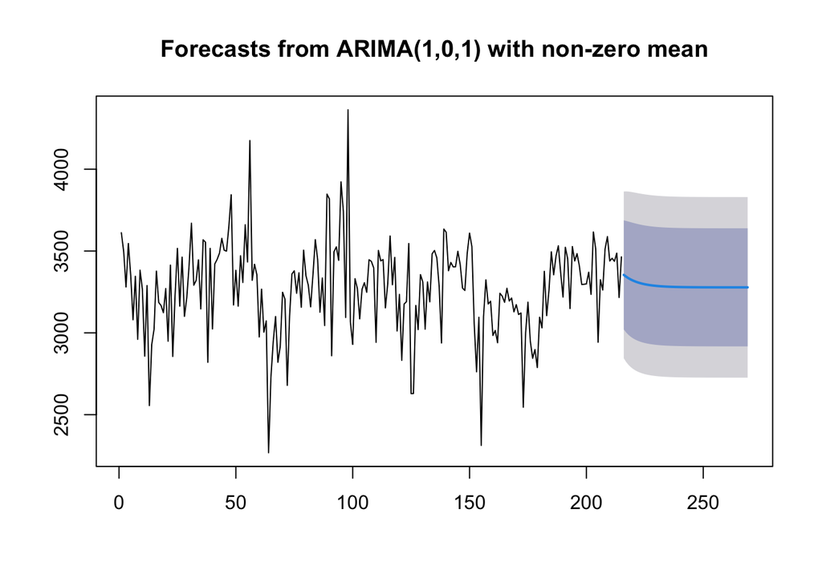

## Forecasts and Impulse Response plots from the VAR model

The VAR model was utilized to obtain forecasts for all 5 numeric features for the 54 weeks following the timeframe in the training data. Below are the 5 plotted forecasts for each of the numeric variables across time. Notably, the VAR forecast for avg_weekly_traffic_volume is quite similar to the ARIMA forecast above. However, there does appear to be slightly more curvature in the VAR forecast.

The forecasts of avg_weekly_temp and avg_weekly_clouds_all (average weekly temperature and average weekly percentage cloud cover) do show a slight continuation of the pattern in the training data. In contrast, the forecasts of avg_weekly_snow_1h and avg_weekly_rain_1h (average weekly amount of rain and average weekly amount of snow) show that they’re forecasted to remain roughly static and close to 0 for the vast majority of the 54 weeks.

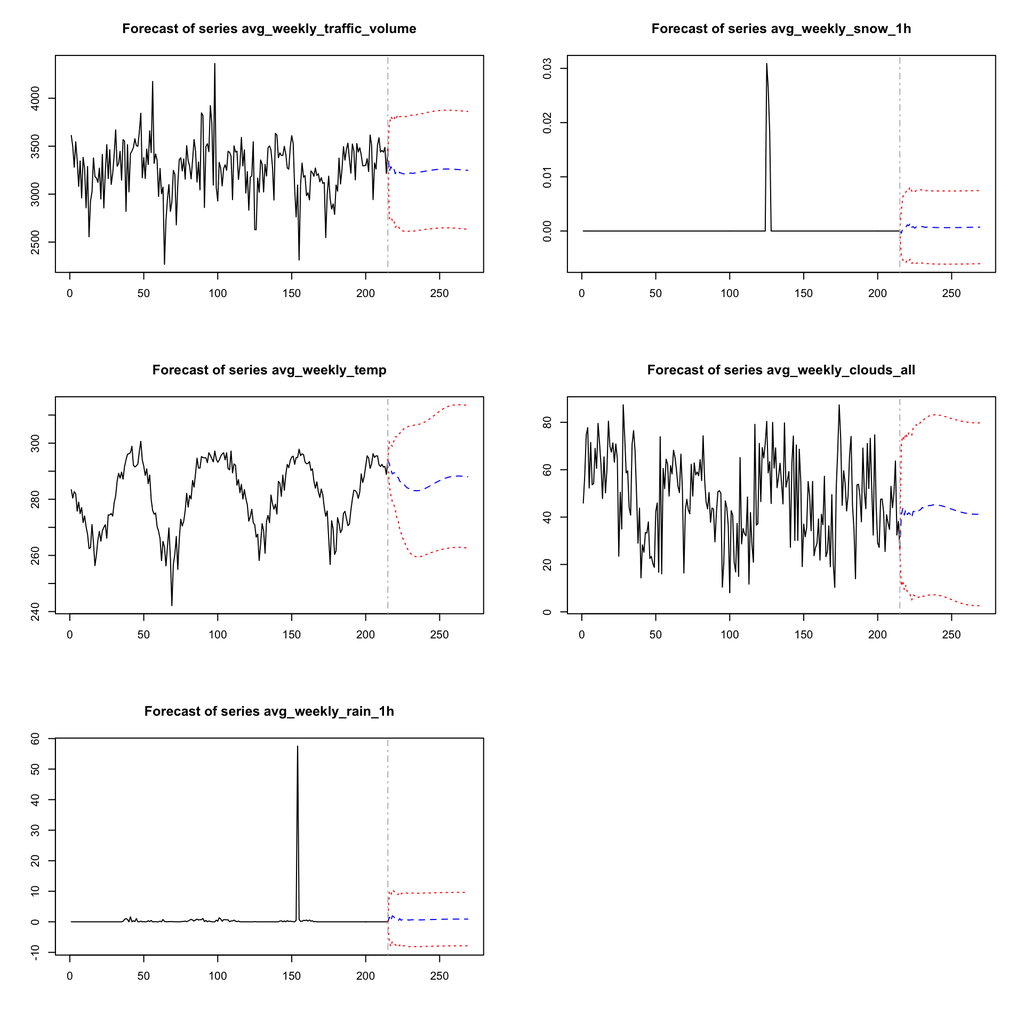

Impulse response plots were also created to evaluate the responses on average weekly traffic value from impulses on each of the four numeric variables.

The impulse response from avg_weekly_temp on avg_weekly_traffic_volume shows that a positive shock in avg_weekly_temp is associated with a sharp increase and then a sharp decrease in avg_weekly_traffic volume. Then, the oscillations taper off and eventually the positive shock in avg_weekly_temp is associated with a general decrease in avg_weekly_traffic_volume.

The impulse response from both avg_weekly_snow_1h and avg_weekly_rain_1h show similar patterns. A positive shock in either feature is first associated with a sharp decline in avg_weekly_traffic_volume, followed by some slight fluctuations that eventually taper off into a horizontal line at 0. The impulse response from avg_weekly_clouds_all roughly follows this same pattern, but with the initial difference that first there is a slight increase, followed by sharp fluctuations that taper off into 0.

Of all of the impulse response visualizations, the association between a positive shock in avg_weekly_temp and avg_weekly_traffic_volume is the most noteworthy in terms of the size and duration of the impact on avg_weekly_traffic_volume.

Below are the impulse response plots.

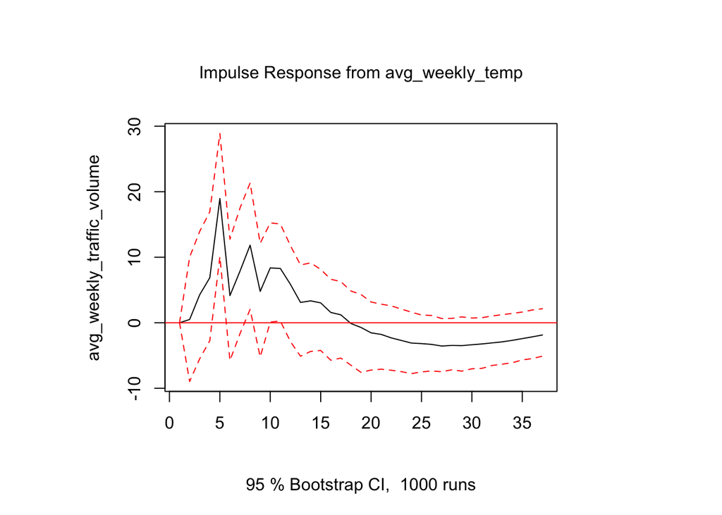

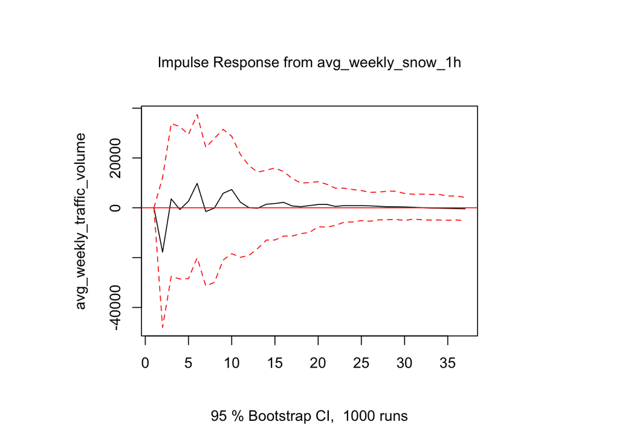

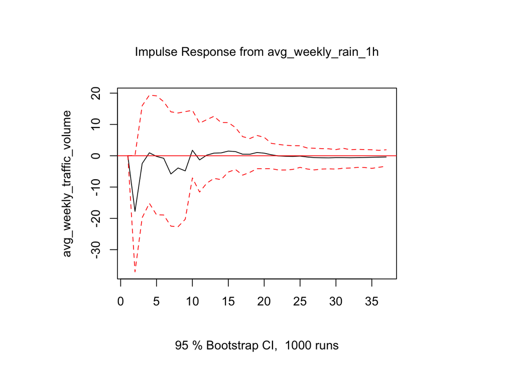

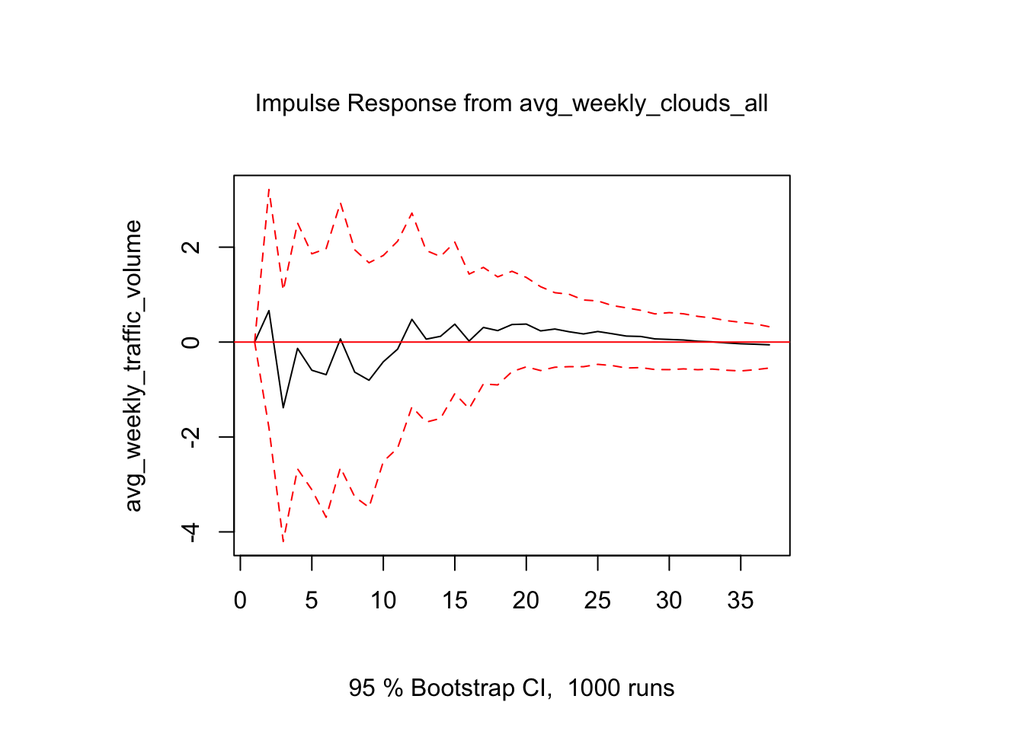

## Plots and table of principal components in the Dynamic Factor Model

The dynamic factor model was built using 4 principal components (PC’s). The table below shows the proportion of variance captured by each PC and the cumulative proportion of variance captured up to that PC.

```
## Importance of components:
##                           PC1    PC2    PC3    PC4
## Standard deviation     1.2406 1.0009 0.9655 0.7258
## Proportion of Variance 0.3848 0.2505 0.2331 0.1317
## Cumulative Proportion  0.3848 0.6352 0.8683 1.0000
```

The visuals below show the values of each PC over time in the training data. Note that the values of PC1 and PC4 fluctuate much more than the values of PC2 and PC3. PC1 and PC4 were also the only two principal components that were statistically significant in the first linear model constructed in this section.

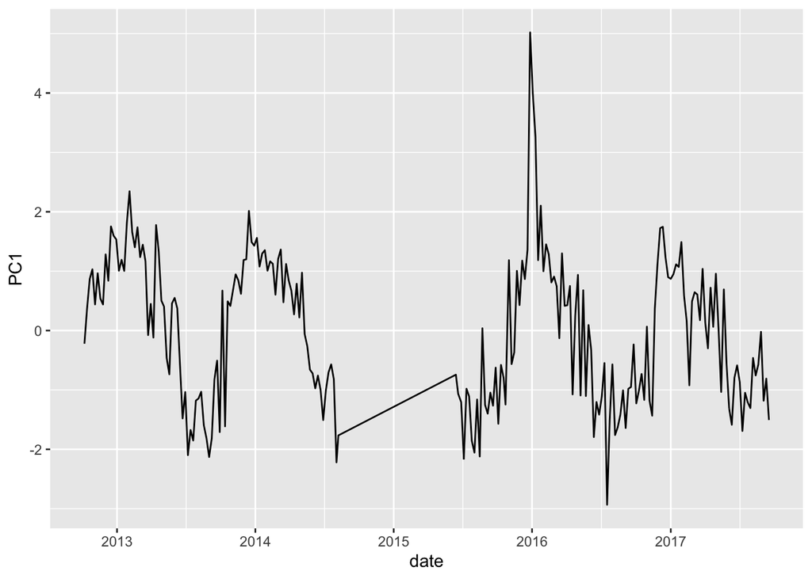

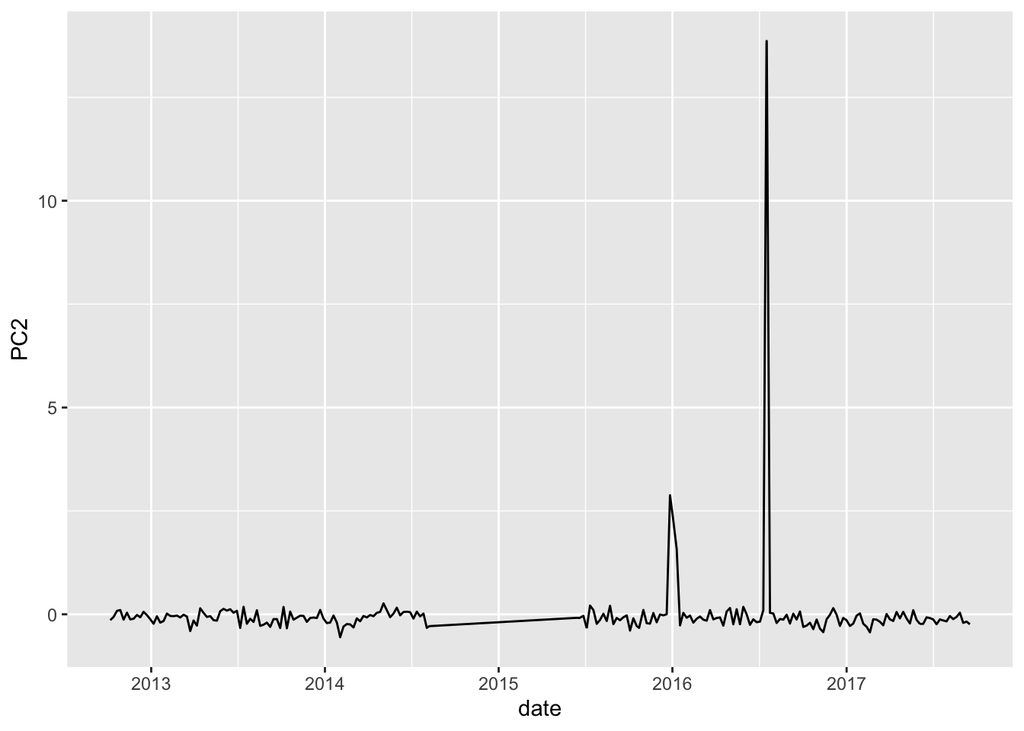

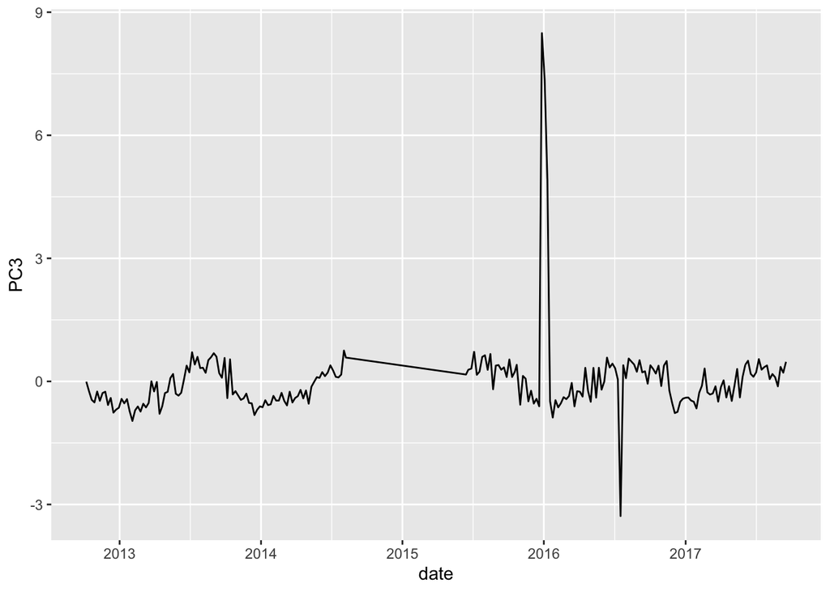

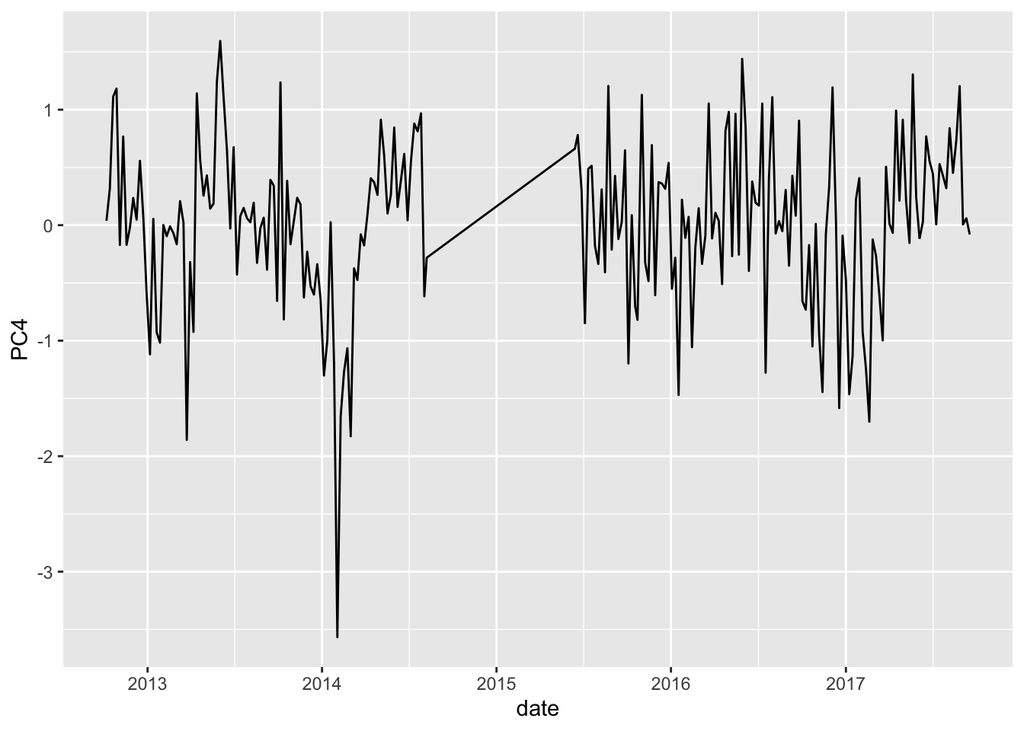